# COVID-19 Analysis Using Spark

Sungjoo Cho

2024-04-10

### Libraries

```r
# library
library(tidyr)
library(lubridate)
library(tidyverse)
library(broom)
library(texreg)
library(knitr)
library(ggplot2)
library(dplyr)
library(haven)
```

### Set up a local Spark server

A local Spark server can be set up by importing the `sparklyr` library.The code below will check the installed version and available Spark versions.

```r
#spark_install(version = "3.5.1")
library(sparklyr)
# check Java version
system("java -version")

# check sparklyr version
packageVersion("sparklyr")
```

```
## [1] '1.8.5'
```

```r
# check available Spark versions
spark_installed_versions()
```

| spark | hadoop | dir |
| --- | --- | --- |
| 2.3.4 | 2.7 | /Users/sungjoocho/spark/spark-2.3.4-bin-hadoop2.7 |
| 3.5.1 | 3 | /Users/sungjoocho/spark/spark-3.5.1-bin-hadoop3 |

### Adding two datasets about COVID-19 and Data cleaning

Two datasets about COVID-19 were obtained from the [GitHub repository](https://github.com/CSSEGISandData/COVID-19/tree/master/csse_covid_19_data).

```r
# get two data sets from github
count_city_github_url <- "https://raw.githubusercontent.com/CSSEGISandData/COVID-19/master/csse_covid_19_data/UID_ISO_FIPS_LookUp_Table.csv?raw=true"
count_city <- read.csv(count_city_github_url)

timeseries_github_url <- "https://raw.githubusercontent.com/CSSEGISandData/COVID-19/master/csse_covid_19_data/csse_covid_19_time_series/time_series_covid19_confirmed_global.csv?raw=true"
timeseries <- read.csv(timeseries_github_url)
```

```r
# drop columns that are in timeseries
count_city <- select(count_city, -Province_State, -Country_Region, -Lat, -Long_)

# change timeseries data to longer format
timeseries_long <- timeseries %>%
  pivot_longer(
    cols = !c(Province.State, Country.Region, Lat, Long),
    names_to = "time",
    values_to = "case"
  )

# change time to month-day-year format
timeseries_long$date <- gsub("^X", "", timeseries_long$time)
timeseries_long$date <- mdy(timeseries_long$date)

# create another variable (number of days since the start of the data collection)
start_date <- min(timeseries_long$date)
timeseries_long <- timeseries_long %>%
  mutate(days = as.numeric(date - start_date))

# create combined key
timeseries_long$Combined_Key <- ifelse(is.na(timeseries_long$Province.State) | timeseries_long$Province.State == "",
                                   timeseries_long$Country.Region,
                                   paste(timeseries_long$Province.State, timeseries_long$Country.Region, sep = ", "))
```

Below are two data sets before they are merged in Spark.

```r
count_city
```

| UID | iso2 | iso3 | code3 | FIPS | Admin2 | Combined_Key | Population |
| --- | --- | --- | --- | --- | --- | --- | --- |
| 4 | AF | AFG | 4 | NA |  | Afghanistan | 38928341 |
| 8 | AL | ALB | 8 | NA |  | Albania | 2877800 |
| 10 | AQ | ATA | 10 | NA |  | Antarctica | NA |
| 12 | DZ | DZA | 12 | NA |  | Algeria | 43851043 |
| 20 | AD | AND | 20 | NA |  | Andorra | 77265 |
| 24 | AO | AGO | 24 | NA |  | Angola | 32866268 |
| 28 | AG | ATG | 28 | NA |  | Antigua and Barbuda | 97928 |
| 32 | AR | ARG | 32 | NA |  | Argentina | 45195777 |
| 51 | AM | ARM | 51 | NA |  | Armenia | 2963234 |
| 40 | AT | AUT | 40 | NA |  | Austria | 9006400 |

[output cut: 4311 more lines]

```r
timeseries_long
```

| Province.State | Country.Region | Lat | Long | time | case | date | days | Combined_Key |
| --- | --- | --- | --- | --- | --- | --- | --- | --- |
|  | Afghanistan | 33.93911 | 67.70995 | X1.22.20 | 0 | 2020-01-22 | 0 | Afghanistan |
|  | Afghanistan | 33.93911 | 67.70995 | X1.23.20 | 0 | 2020-01-23 | 1 | Afghanistan |
|  | Afghanistan | 33.93911 | 67.70995 | X1.24.20 | 0 | 2020-01-24 | 2 | Afghanistan |
|  | Afghanistan | 33.93911 | 67.70995 | X1.25.20 | 0 | 2020-01-25 | 3 | Afghanistan |
|  | Afghanistan | 33.93911 | 67.70995 | X1.26.20 | 0 | 2020-01-26 | 4 | Afghanistan |
|  | Afghanistan | 33.93911 | 67.70995 | X1.27.20 | 0 | 2020-01-27 | 5 | Afghanistan |
|  | Afghanistan | 33.93911 | 67.70995 | X1.28.20 | 0 | 2020-01-28 | 6 | Afghanistan |
|  | Afghanistan | 33.93911 | 67.70995 | X1.29.20 | 0 | 2020-01-29 | 7 | Afghanistan |
|  | Afghanistan | 33.93911 | 67.70995 | X1.30.20 | 0 | 2020-01-30 | 8 | Afghanistan |
|  | Afghanistan | 33.93911 | 67.70995 | X1.31.20 | 0 | 2020-01-31 | 9 | Afghanistan |

[output cut: 9990 more lines]

### Merging two datasets in Spark

In Spark, two datasets were merged with a smaller version that includes only: Germany, China, Japan, United Kingdom, US, Brazil, and Mexico. To connect to the local cluster, `spark_connect()` was used.

```r
# set up a local Spark connection
sc <- spark_connect(master = "local")

# copying datasets into Spark
city <- copy_to(sc, count_city, overwrite = TRUE)
time <- copy_to(sc, timeseries_long, overwrite = TRUE)

# merging data
covid_full <- time %>%
  left_join(city, by = "Combined_Key")

# selected countries
sel_countries <- c("Germany", "China", "Japan", "United Kingdom", "US", "Brazil", "Mexico")
covid <- covid_full %>%
  filter(Country_Region %in% sel_countries)
```

Below is the merged dataset in Spark that includes only seven countries.

```r
covid
```

| Province_State | Country_Region | Lat | Long | time | case | date | days | Combined_Key | UID | iso2 | iso3 | code3 | FIPS | Admin2 | Population |
| --- | --- | --- | --- | --- | --- | --- | --- | --- | --- | --- | --- | --- | --- | --- | --- |
|  | Brazil | -14.235 | -51.9253 | X1.22.20 | 0 | 2020-01-22 | 0 | Brazil | 76 | BR | BRA | 76 | NA |  | 212559409 |
|  | Brazil | -14.235 | -51.9253 | X1.23.20 | 0 | 2020-01-23 | 1 | Brazil | 76 | BR | BRA | 76 | NA |  | 212559409 |
|  | Brazil | -14.235 | -51.9253 | X1.24.20 | 0 | 2020-01-24 | 2 | Brazil | 76 | BR | BRA | 76 | NA |  | 212559409 |
|  | Brazil | -14.235 | -51.9253 | X1.25.20 | 0 | 2020-01-25 | 3 | Brazil | 76 | BR | BRA | 76 | NA |  | 212559409 |
|  | Brazil | -14.235 | -51.9253 | X1.26.20 | 0 | 2020-01-26 | 4 | Brazil | 76 | BR | BRA | 76 | NA |  | 212559409 |
|  | Brazil | -14.235 | -51.9253 | X1.27.20 | 0 | 2020-01-27 | 5 | Brazil | 76 | BR | BRA | 76 | NA |  | 212559409 |
|  | Brazil | -14.235 | -51.9253 | X1.28.20 | 0 | 2020-01-28 | 6 | Brazil | 76 | BR | BRA | 76 | NA |  | 212559409 |
|  | Brazil | -14.235 | -51.9253 | X1.29.20 | 0 | 2020-01-29 | 7 | Brazil | 76 | BR | BRA | 76 | NA |  | 212559409 |
|  | Brazil | -14.235 | -51.9253 | X1.30.20 | 0 | 2020-01-30 | 8 | Brazil | 76 | BR | BRA | 76 | NA |  | 212559409 |
|  | Brazil | -14.235 | -51.9253 | X1.31.20 | 0 | 2020-01-31 | 9 | Brazil | 76 | BR | BRA | 76 | NA |  | 212559409 |

[output cut: 990 more lines]

```r
# save original dataset locally
#save(covid, file = "data/covid.csv")
```

### Calculating the number of cases and rate of cases (cases/population) by country and day and Creating two graphs and interpreting them: change in the number of cases and change in rate by country.

The summary table and graphs below show the change in the number of cases by country over time. All seven countries exhibit increasing trends in the number of COVID cases over time. Notably, US has experienced particularly rapid increases in the number of cases, while other countries show a more steady trend.

```r
# calculate the number of cases by country and day
tab_change_case <- covid %>%
  group_by(Country_Region, days) %>%
  summarise(sum_case = sum(case, na.rm = TRUE),
            .groups = "drop")
tab_change_case
```

| Country_Region | days | sum_case |
| --- | --- | --- |
| China | 1 | 643 |
| United Kingdom | 1 | 0 |
| Japan | 1 | 2 |
| Germany | 1 | 0 |
| China | 18 | 39829 |
| China | 21 | 44759 |
| China | 46 | 80823 |
| China | 50 | 80932 |
| China | 67 | 82058 |
| China | 70 | 84002 |

[output cut: 990 more lines]

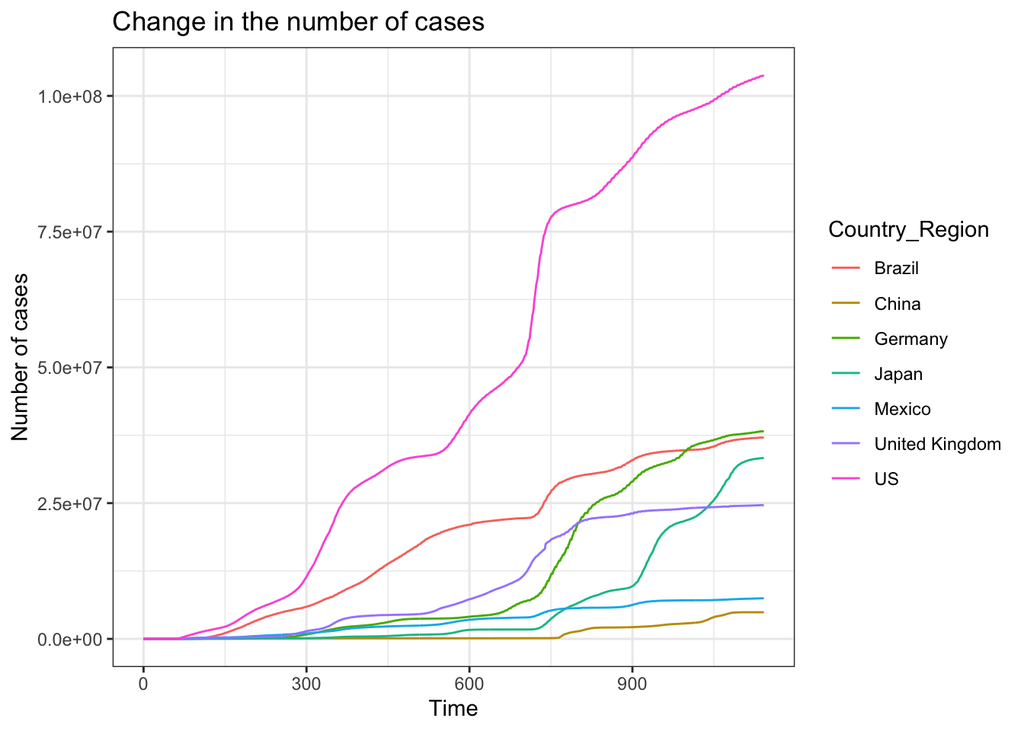

```r
ggplot(data=tab_change_case, aes(days, sum_case, color = Country_Region)) +
  geom_line() +
  theme_bw() +
  labs(x = "Time",
       y = "Number of cases",
       title = "Change in the number of cases")
```

Furthermore, the summary table and graphs below illustrate the change in the rate of cases by country over time. The rate of cases was calculated as (cases/population). It shows that the rate of cases is significantly and rapidly increasing over time in the United Kingdom, whereas other countries exhibit a more steady trend.

```r
# calculate rate of cases (cases/population) by country and day
tab_change_rate <- covid %>%
  group_by(Country_Region, days) %>%
  summarise(sum_case = sum(case, na.rm = TRUE),
            population = mean(Population, na.rm = T),
            .groups = "drop") %>%
  mutate(rate = (sum_case / population))
tab_change_rate
```

| Country_Region | days | sum_case | population | rate |
| --- | --- | --- | --- | --- |
| China | 1 | 643 | 42967426 | 1.496482e-05 |
| United Kingdom | 1 | 0 | 4571579 | 0.000000e+00 |
| Japan | 1 | 2 | 126476458 | 1.581322e-08 |
| Germany | 1 | 0 | 83155031 | 0.000000e+00 |
| China | 18 | 39829 | 42967426 | 9.269580e-04 |
| China | 21 | 44759 | 42967426 | 1.041696e-03 |
| China | 46 | 80823 | 42967426 | 1.881030e-03 |
| China | 50 | 80932 | 42967426 | 1.883566e-03 |
| China | 67 | 82058 | 42967426 | 1.909772e-03 |
| China | 70 | 84002 | 42967426 | 1.955016e-03 |

[output cut: 990 more lines]

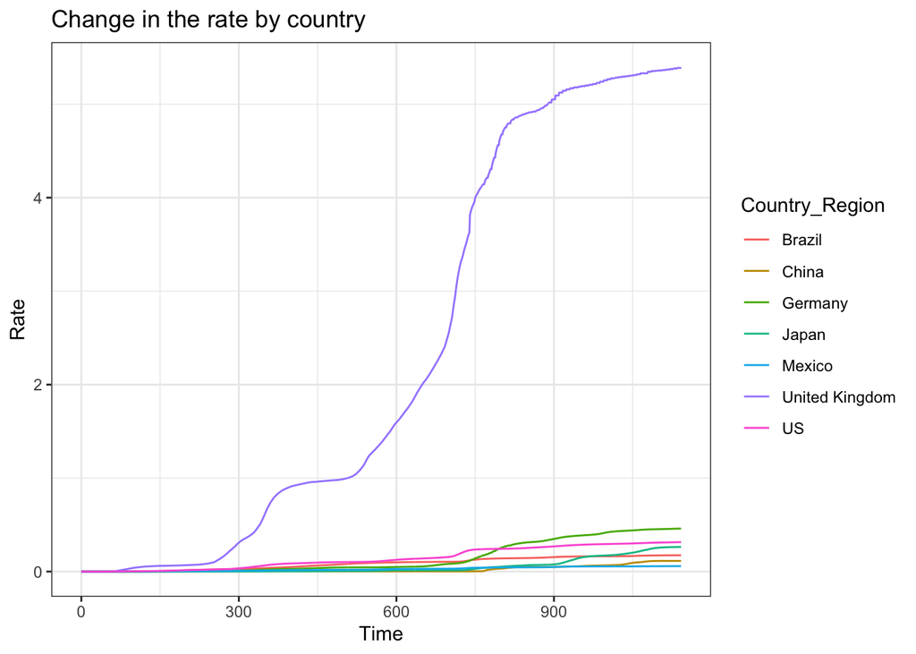

```r
ggplot(data=tab_change_rate, aes(days, rate, color = Country_Region)) +
  geom_line() +
  theme_bw() +
  labs(x = "Time",
       y = "Rate",
       title = "Change in the rate by country")
```

### Fitting a ml_linear_regression explaining the log of number of cases using: country, population size and day since the start of the pandemic. Interpret the results.

Next, a linear model was fitted to approximate the relationship between the log number of cases and three predictors: country, population size, and day since of the pandemic. The `ml_linear_regression()` function was used for this analysis. The table presented below displays the output from the regression model. The United States was used as a reference category in this model.

It indicates that all predictors (country, population, and days) significantly influence the log number of COVID19 cases (p<0.05). Holding all other predictors constant, the log number of cases is higher in all other countries than that of the US. Additionally, the one-unit increase in the number of days results in a increase of 0.0043287 in the log number of cases, when all other predictors are hold constant.

```r
# log case and remove NA in Population variable
covid <- covid %>%
  mutate(log_case = log(case+1)) %>%
  filter(!is.na(Population))

# log number of cases
model <- ml_linear_regression(covid, log_case ~ Country_Region + Population + days)
```

```r
# coefficients
coeff <- tidy(model)
kable(coeff, caption = "Coefficients of regression model")
```

Coefficients of regression model

| term | estimate | std.error | statistic | p.value |
| --- | --- | --- | --- | --- |
| (Intercept) | 2.0735418 | 0.1473887 | 14.068528 | 0.0e+00 |
| Country_Region_China | 0.6463879 | 0.1328440 | 4.865765 | 1.1e-06 |
| Country_Region_United Kingdom | 1.3025076 | 0.1460547 | 8.917946 | 0.0e+00 |
| Country_Region_Brazil | 3.1833170 | 0.1121814 | 28.376520 | 0.0e+00 |
| Country_Region_Germany | 7.0732186 | 0.1399199 | 50.551903 | 0.0e+00 |
| Country_Region_Japan | 4.2865586 | 0.1291576 | 33.188583 | 0.0e+00 |
| Country_Region_Mexico | 4.6086747 | 0.1288506 | 35.767590 | 0.0e+00 |
| Population | 0.0000000 | 0.0000000 | 93.774942 | 0.0e+00 |
| days | 0.0043287 | 0.0000302 | 143.157712 | 0.0e+00 |

```r
# regression model table
htmlreg(model, caption = "Output from regression model")
```

Output from regression model

|  | Model 1 |
| --- | --- |
| (Intercept) | 2.07*** |
|  | (0.15) |
| Country_Region_China | 0.65*** |
|  | (0.13) |
| Country_Region_United Kingdom | 1.30*** |
|  | (0.15) |
| Country_Region_Brazil | 3.18*** |
|  | (0.11) |
| Country_Region_Germany | 7.07*** |
|  | (0.14) |
| Country_Region_Japan | 4.29*** |
|  | (0.13) |
| Country_Region_Mexico | 4.61*** |
|  | (0.13) |
| Population | 0.00*** |
|  | (0.00) |
| days | 0.00*** |
|  | (0.00) |
| explained.variance | 8.91 |
| mean.absolute.error | 1.75 |
| mean.squared.error | 6.03 |
| R<sup>2</sup> | 0.60 |
| root.mean.squared.error | 2.46 |

***p < 0.001; **p < 0.01; *p < 0.05